# W3cubDocs

/GTK 3.24

# GtkStyleContext

GtkStyleContext — Rendering UI elements

## Functions

| GtkStyleContext * | gtk_style_context_new () |
| --- | --- |
| void | gtk_style_context_add_provider () |
| void | gtk_style_context_add_provider_for_screen () |
| void | gtk_style_context_get () |
| GtkTextDirection | gtk_style_context_get_direction () |
| GtkJunctionSides | gtk_style_context_get_junction_sides () |
| GtkStyleContext * | gtk_style_context_get_parent () |
| const GtkWidgetPath * | gtk_style_context_get_path () |
| void | gtk_style_context_get_property () |
| [GdkScreen](https://developer.gnome.org/gtk3/html/GdkScreen.html#GdkScreen-struct) * | gtk_style_context_get_screen () |
| [GdkFrameClock](https://developer.gnome.org/gtk3/html/GdkFrameClock.html#GdkFrameClock-struct) * | gtk_style_context_get_frame_clock () |
| GtkStateFlags | gtk_style_context_get_state () |
| void | gtk_style_context_get_style () |
| void | gtk_style_context_get_style_property () |
| void | gtk_style_context_get_style_valist () |
| void | gtk_style_context_get_valist () |
| GtkCssSection * | gtk_style_context_get_section () |
| void | gtk_style_context_get_color () |
| void | gtk_style_context_get_background_color () |
| void | gtk_style_context_get_border_color () |
| void | gtk_style_context_get_border () |
| void | gtk_style_context_get_padding () |
| void | gtk_style_context_get_margin () |
| const [PangoFontDescription](https://developer.gnome.org/pango/stable/pango-Fonts.html#PangoFontDescription-struct) * | gtk_style_context_get_font () |
| void | gtk_style_context_invalidate () |
| gboolean | gtk_style_context_state_is_running () |
| gboolean | gtk_style_context_lookup_color () |
| GtkIconSet * | gtk_style_context_lookup_icon_set () |
| void | gtk_style_context_notify_state_change () |
| void | gtk_style_context_pop_animatable_region () |
| void | gtk_style_context_push_animatable_region () |
| void | gtk_style_context_cancel_animations () |
| void | gtk_style_context_scroll_animations () |
| void | gtk_style_context_remove_provider () |
| void | gtk_style_context_remove_provider_for_screen () |
| void | gtk_style_context_reset_widgets () |
| void | gtk_style_context_set_background () |
| void | gtk_style_context_restore () |
| void | gtk_style_context_save () |
| void | gtk_style_context_set_direction () |
| void | gtk_style_context_set_junction_sides () |
| void | gtk_style_context_set_parent () |
| void | gtk_style_context_set_path () |
| void | gtk_style_context_add_class () |
| void | gtk_style_context_remove_class () |
| gboolean | gtk_style_context_has_class () |
| GList * | gtk_style_context_list_classes () |
| void | gtk_style_context_add_region () |
| void | gtk_style_context_remove_region () |
| gboolean | gtk_style_context_has_region () |
| GList * | gtk_style_context_list_regions () |
| void | gtk_style_context_set_screen () |
| void | gtk_style_context_set_frame_clock () |
| void | gtk_style_context_set_state () |
| void | gtk_style_context_set_scale () |
| gint | gtk_style_context_get_scale () |
| char * | gtk_style_context_to_string () |
| GtkBorder * | gtk_border_new () |
| GtkBorder * | gtk_border_copy () |
| void | gtk_border_free () |
| void | gtk_render_arrow () |
| void | gtk_render_background () |
| void | gtk_render_background_get_clip () |
| void | gtk_render_check () |
| void | gtk_render_expander () |
| void | gtk_render_extension () |
| void | gtk_render_focus () |
| void | gtk_render_frame () |
| void | gtk_render_frame_gap () |
| void | gtk_render_handle () |
| void | gtk_render_layout () |
| void | gtk_render_line () |
| void | gtk_render_option () |
| void | gtk_render_slider () |
| void | gtk_render_activity () |
| [GdkPixbuf](https://developer.gnome.org/gdk-pixbuf/unstable//gdk-pixbuf-The-GdkPixbuf-Structure.html#GdkPixbuf-struct) * | gtk_render_icon_pixbuf () |
| void | gtk_render_icon_surface () |
| void | gtk_render_icon () |
| void | gtk_render_insertion_cursor () |

## Properties

| GtkTextDirection | direction | Read / Write |
| --- | --- | --- |
| [GdkFrameClock](https://developer.gnome.org/gtk3/html/GdkFrameClock.html#GdkFrameClock-struct) * | paint-clock | Read / Write |
| GtkStyleContext * | parent | Read / Write |
| [GdkScreen](https://developer.gnome.org/gtk3/html/GdkScreen.html#GdkScreen-struct) * | screen | Read / Write |

## Signals

| void | changed | Run First |
| --- | --- | --- |

## Types and Values

| #define | GTK_STYLE_PROPERTY_BACKGROUND_COLOR |
| --- | --- |
| #define | GTK_STYLE_PROPERTY_COLOR |
| #define | GTK_STYLE_PROPERTY_FONT |
| #define | GTK_STYLE_PROPERTY_MARGIN |
| #define | GTK_STYLE_PROPERTY_PADDING |
| #define | GTK_STYLE_PROPERTY_BORDER_WIDTH |
| #define | GTK_STYLE_PROPERTY_BORDER_RADIUS |
| #define | GTK_STYLE_PROPERTY_BORDER_STYLE |
| #define | GTK_STYLE_PROPERTY_BORDER_COLOR |
| #define | GTK_STYLE_PROPERTY_BACKGROUND_IMAGE |
| enum | GtkBorderStyle |
| #define | GTK_STYLE_CLASS_ACCELERATOR |
| #define | GTK_STYLE_CLASS_ARROW |
| #define | GTK_STYLE_CLASS_BACKGROUND |
| #define | GTK_STYLE_CLASS_BOTTOM |
| #define | GTK_STYLE_CLASS_BUTTON |
| #define | GTK_STYLE_CLASS_CALENDAR |
| #define | GTK_STYLE_CLASS_CELL |
| #define | GTK_STYLE_CLASS_COMBOBOX_ENTRY |
| #define | GTK_STYLE_CLASS_CONTEXT_MENU |
| #define | GTK_STYLE_CLASS_CHECK |
| #define | GTK_STYLE_CLASS_CSD |
| #define | GTK_STYLE_CLASS_CURSOR_HANDLE |
| #define | GTK_STYLE_CLASS_DEFAULT |
| #define | GTK_STYLE_CLASS_DESTRUCTIVE_ACTION |
| #define | GTK_STYLE_CLASS_DIM_LABEL |
| #define | GTK_STYLE_CLASS_DND |
| #define | GTK_STYLE_CLASS_DOCK |
| #define | GTK_STYLE_CLASS_ENTRY |
| #define | GTK_STYLE_CLASS_ERROR |
| #define | GTK_STYLE_CLASS_EXPANDER |

[output cut: 73 more lines]

## Object Hierarchy

```
    GBoxed
    ╰── GtkBorder
    GObject
    ╰── GtkStyleContext
```

## Includes

```
#include <gtk/gtk.h>
```

## Description

GtkStyleContext is an object that stores styling information affecting a widget defined by GtkWidgetPath.

In order to construct the final style information, GtkStyleContext queries information from all attached GtkStyleProviders. Style providers can be either attached explicitly to the context through `gtk_style_context_add_provider()`, or to the screen through `gtk_style_context_add_provider_for_screen()`. The resulting style is a combination of all providers’ information in priority order.

For GTK+ widgets, any GtkStyleContext returned by `gtk_widget_get_style_context()` will already have a GtkWidgetPath, a [GdkScreen](https://developer.gnome.org/gtk3/html/GdkScreen.html#GdkScreen-struct) and RTL/LTR information set. The style context will also be updated automatically if any of these settings change on the widget.

If you are using the theming layer standalone, you will need to set a widget path and a screen yourself to the created style context through `gtk_style_context_set_path()` and possibly `gtk_style_context_set_screen()`. See the “Foreign drawing“ example in gtk3-demo.

### Style Classes

Widgets can add style classes to their context, which can be used to associate different styles by class. The documentation for individual widgets lists which style classes it uses itself, and which style classes may be added by applications to affect their appearance.

GTK+ defines macros for a number of style classes.

### Style Regions

Widgets can also add regions with flags to their context. This feature is deprecated and will be removed in a future GTK+ update. Please use style classes instead.

GTK+ defines macros for a number of style regions.

### Custom styling in UI libraries and applications

If you are developing a library with custom GtkWidgets that render differently than standard components, you may need to add a GtkStyleProvider yourself with the `GTK_STYLE_PROVIDER_PRIORITY_FALLBACK` priority, either a GtkCssProvider or a custom object implementing the GtkStyleProvider interface. This way themes may still attempt to style your UI elements in a different way if needed so.

If you are using custom styling on an applications, you probably want then to make your style information prevail to the theme’s, so you must use a GtkStyleProvider with the `GTK_STYLE_PROVIDER_PRIORITY_APPLICATION` priority, keep in mind that the user settings in `XDG_CONFIG_HOME/gtk-3.0/gtk.css` will still take precedence over your changes, as it uses the `GTK_STYLE_PROVIDER_PRIORITY_USER` priority.

## Functions

### gtk_style_context_new ()

```
GtkStyleContext *
gtk_style_context_new (void);
```

Creates a standalone GtkStyleContext, this style context won’t be attached to any widget, so you may want to call `gtk_style_context_set_path()` yourself.

This function is only useful when using the theming layer separated from GTK+, if you are using GtkStyleContext to theme GtkWidgets, use `gtk_widget_get_style_context()` in order to get a style context ready to theme the widget.

#### Returns

A newly created GtkStyleContext.

### gtk_style_context_add_provider ()

```
void
gtk_style_context_add_provider (GtkStyleContext *context,
                                GtkStyleProvider *provider,
                                guint priority);
```

Adds a style provider to *`context`* , to be used in style construction. Note that a style provider added by this function only affects the style of the widget to which *`context`* belongs. If you want to affect the style of all widgets, use `gtk_style_context_add_provider_for_screen()`.

Note: If both priorities are the same, a GtkStyleProvider added through this function takes precedence over another added through `gtk_style_context_add_provider_for_screen()`.

#### Parameters

[output not shown]

Since: 3.0

### gtk_style_context_add_provider_for_screen ()

```
void
gtk_style_context_add_provider_for_screen
                               (GdkScreen *screen,
                                GtkStyleProvider *provider,
                                guint priority);
```

Adds a global style provider to *`screen`* , which will be used in style construction for all GtkStyleContexts under *`screen`* .

GTK+ uses this to make styling information from GtkSettings available.

Note: If both priorities are the same, A GtkStyleProvider added through `gtk_style_context_add_provider()` takes precedence over another added through this function.

#### Parameters

[output not shown]

Since: 3.0

### gtk_style_context_get ()

```
void
gtk_style_context_get (GtkStyleContext *context,
                       GtkStateFlags state,
                       ...);
```

Retrieves several style property values from *`context`* for a given state.

See `gtk_style_context_get_property()` for details.

#### Parameters

| context | a GtkStyleContext |  |
| --- | --- | --- |
| state | state to retrieve the property values for |  |
| ... | property name /return value pairs, followed by `NULL` |  |

Since: 3.0

### gtk_style_context_get_direction ()

```
GtkTextDirection
gtk_style_context_get_direction (GtkStyleContext *context);
```

`gtk_style_context_get_direction` has been deprecated since version 3.8 and should not be used in newly-written code.

Use `gtk_style_context_get_state()` and check for GTK_STATE_FLAG_DIR_LTR and GTK_STATE_FLAG_DIR_RTL instead.

Returns the widget direction used for rendering.

#### Parameters

| context | a GtkStyleContext |  |
| --- | --- | --- |

#### Returns

the widget direction

Since: 3.0

### gtk_style_context_get_junction_sides ()

```
GtkJunctionSides
gtk_style_context_get_junction_sides (GtkStyleContext *context);
```

Returns the sides where rendered elements connect visually with others.

#### Parameters

| context | a GtkStyleContext |  |
| --- | --- | --- |

#### Returns

the junction sides

Since: 3.0

### gtk_style_context_get_parent ()

```
GtkStyleContext *
gtk_style_context_get_parent (GtkStyleContext *context);
```

Gets the parent context set via `gtk_style_context_set_parent()`. See that function for details.

#### Parameters

| context | a GtkStyleContext |  |
| --- | --- | --- |

#### Returns

the parent context or `NULL`.

[nullable][transfer none]

Since: 3.4

### gtk_style_context_get_path ()

```
const GtkWidgetPath *
gtk_style_context_get_path (GtkStyleContext *context);
```

Returns the widget path used for style matching.

#### Parameters

| context | a GtkStyleContext |  |
| --- | --- | --- |

#### Returns

A GtkWidgetPath.

[transfer none]

Since: 3.0

### gtk_style_context_get_property ()

```
void
gtk_style_context_get_property (GtkStyleContext *context,
                                const gchar *property,
                                GtkStateFlags state,
                                GValue *value);
```

Gets a style property from *`context`* for the given state.

Note that not all CSS properties that are supported by GTK+ can be retrieved in this way, since they may not be representable as GValue. GTK+ defines macros for a number of properties that can be used with this function.

Note that passing a state other than the current state of *`context`* is not recommended unless the style context has been saved with `gtk_style_context_save()`.

When *`value`* is no longer needed, `g_value_unset()` must be called to free any allocated memory.

#### Parameters

| context | a GtkStyleContext |  |
| --- | --- | --- |
| property | style property name |  |
| state | state to retrieve the property value for |  |
| value | return location for the style property value. | [out][transfer full] |

Since: 3.0

### gtk_style_context_get_screen ()

```
GdkScreen *
gtk_style_context_get_screen (GtkStyleContext *context);
```

Returns the [GdkScreen](https://developer.gnome.org/gtk3/html/GdkScreen.html#GdkScreen-struct) to which *`context`* is attached.

#### Parameters

| context | a GtkStyleContext |  |
| --- | --- | --- |

#### Returns

a [GdkScreen](https://developer.gnome.org/gtk3/html/GdkScreen.html#GdkScreen-struct).

[transfer none]

### gtk_style_context_get_frame_clock ()

```
GdkFrameClock *
gtk_style_context_get_frame_clock (GtkStyleContext *context);
```

Returns the [GdkFrameClock](https://developer.gnome.org/gtk3/html/GdkFrameClock.html#GdkFrameClock-struct) to which *`context`* is attached.

#### Parameters

| context | a GtkStyleContext |  |
| --- | --- | --- |

#### Returns

a [GdkFrameClock](https://developer.gnome.org/gtk3/html/GdkFrameClock.html#GdkFrameClock-struct), or `NULL` if *`context`* does not have an attached frame clock.

[nullable][transfer none]

Since: 3.8

### gtk_style_context_get_state ()

```
GtkStateFlags
gtk_style_context_get_state (GtkStyleContext *context);
```

Returns the state used for style matching.

This method should only be used to retrieve the GtkStateFlags to pass to GtkStyleContext methods, like `gtk_style_context_get_padding()`. If you need to retrieve the current state of a GtkWidget, use `gtk_widget_get_state_flags()`.

#### Parameters

| context | a GtkStyleContext |  |
| --- | --- | --- |

#### Returns

the state flags

Since: 3.0

### gtk_style_context_get_style ()

```
void
gtk_style_context_get_style (GtkStyleContext *context,
                             ...);
```

Retrieves several widget style properties from *`context`* according to the current style.

#### Parameters

| context | a GtkStyleContext |  |
| --- | --- | --- |
| ... | property name /return value pairs, followed by `NULL` |  |

Since: 3.0

### gtk_style_context_get_style_property ()

```
void
gtk_style_context_get_style_property (GtkStyleContext *context,
                                      const gchar *property_name,
                                      GValue *value);
```

Gets the value for a widget style property.

When *`value`* is no longer needed, `g_value_unset()` must be called to free any allocated memory.

#### Parameters

| context | a GtkStyleContext |  |
| --- | --- | --- |
| property_name | the name of the widget style property |  |
| value | Return location for the property value |  |

### gtk_style_context_get_style_valist ()

```
void
gtk_style_context_get_style_valist (GtkStyleContext *context,
                                    va_list args);
```

Retrieves several widget style properties from *`context`* according to the current style.

#### Parameters

| context | a GtkStyleContext |  |
| --- | --- | --- |
| args | va_list of property name/return location pairs, followed by `NULL` |  |

Since: 3.0

### gtk_style_context_get_valist ()

```
void
gtk_style_context_get_valist (GtkStyleContext *context,
                              GtkStateFlags state,
                              va_list args);
```

Retrieves several style property values from *`context`* for a given state.

See `gtk_style_context_get_property()` for details.

#### Parameters

| context | a GtkStyleContext |  |
| --- | --- | --- |
| state | state to retrieve the property values for |  |
| args | va_list of property name/return location pairs, followed by `NULL` |  |

Since: 3.0

### gtk_style_context_get_section ()

```
GtkCssSection *
gtk_style_context_get_section (GtkStyleContext *context,
                               const gchar *property);
```

Queries the location in the CSS where *`property`* was defined for the current *`context`* . Note that the state to be queried is taken from `gtk_style_context_get_state()`.

If the location is not available, `NULL` will be returned. The location might not be available for various reasons, such as the property being overridden, *`property`* not naming a supported CSS property or tracking of definitions being disabled for performance reasons.

Shorthand CSS properties cannot be queried for a location and will always return `NULL`.

#### Parameters

| context | a GtkStyleContext |  |
| --- | --- | --- |
| property | style property name |  |

#### Returns

`NULL` or the section where a value for *`property`* was defined.

[nullable][transfer none]

### gtk_style_context_get_color ()

```
void
gtk_style_context_get_color (GtkStyleContext *context,
                             GtkStateFlags state,
                             GdkRGBA *color);
```

Gets the foreground color for a given state.

See `gtk_style_context_get_property()` and GTK_STYLE_PROPERTY_COLOR for details.

#### Parameters

| context | a GtkStyleContext |  |
| --- | --- | --- |
| state | state to retrieve the color for |  |
| color | return value for the foreground color. | [out] |

Since: 3.0

### gtk_style_context_get_background_color ()

```
void
gtk_style_context_get_background_color
                               (GtkStyleContext *context,
                                GtkStateFlags state,
                                GdkRGBA *color);
```

`gtk_style_context_get_background_color` has been deprecated since version 3.16 and should not be used in newly-written code.

Use `gtk_render_background()` instead.

Gets the background color for a given state.

This function is far less useful than it seems, and it should not be used in newly written code. CSS has no concept of "background color", as a background can be an image, or a gradient, or any other pattern including solid colors.

The only reason why you would call `gtk_style_context_get_background_color()` is to use the returned value to draw the background with it; the correct way to achieve this result is to use `gtk_render_background()` instead, along with CSS style classes to modify the color to be rendered.

#### Parameters

| context | a GtkStyleContext |  |
| --- | --- | --- |
| state | state to retrieve the color for |  |
| color | return value for the background color. | [out] |

Since: 3.0

### gtk_style_context_get_border_color ()

```
void
gtk_style_context_get_border_color (GtkStyleContext *context,
                                    GtkStateFlags state,
                                    GdkRGBA *color);
```

`gtk_style_context_get_border_color` has been deprecated since version 3.16 and should not be used in newly-written code.

Use `gtk_render_frame()` instead.

Gets the border color for a given state.

#### Parameters

| context | a GtkStyleContext |  |
| --- | --- | --- |
| state | state to retrieve the color for |  |
| color | return value for the border color. | [out] |

Since: 3.0

### gtk_style_context_get_border ()

```
void
gtk_style_context_get_border (GtkStyleContext *context,
                              GtkStateFlags state,
                              GtkBorder *border);
```

Gets the border for a given state as a GtkBorder.

See `gtk_style_context_get_property()` and GTK_STYLE_PROPERTY_BORDER_WIDTH for details.

#### Parameters

| context | a GtkStyleContext |  |
| --- | --- | --- |
| state | state to retrieve the border for |  |
| border | return value for the border settings. | [out] |

Since: 3.0

### gtk_style_context_get_padding ()

```
void
gtk_style_context_get_padding (GtkStyleContext *context,
                               GtkStateFlags state,
                               GtkBorder *padding);
```

Gets the padding for a given state as a GtkBorder. See `gtk_style_context_get()` and GTK_STYLE_PROPERTY_PADDING for details.

#### Parameters

| context | a GtkStyleContext |  |
| --- | --- | --- |
| state | state to retrieve the padding for |  |
| padding | return value for the padding settings. | [out] |

Since: 3.0

### gtk_style_context_get_margin ()

```
void
gtk_style_context_get_margin (GtkStyleContext *context,
                              GtkStateFlags state,
                              GtkBorder *margin);
```

Gets the margin for a given state as a GtkBorder. See `gtk_style_property_get()` and GTK_STYLE_PROPERTY_MARGIN for details.

#### Parameters

| context | a GtkStyleContext |  |
| --- | --- | --- |
| state | state to retrieve the border for |  |
| margin | return value for the margin settings. | [out] |

Since: 3.0

### gtk_style_context_get_font ()

```
const PangoFontDescription *
gtk_style_context_get_font (GtkStyleContext *context,
                            GtkStateFlags state);
```

`gtk_style_context_get_font` has been deprecated since version 3.8 and should not be used in newly-written code.

Use `gtk_style_context_get()` for "font" or subproperties instead.

Returns the font description for a given state. The returned object is const and will remain valid until the “changed” signal happens.

#### Parameters

| context | a GtkStyleContext |  |
| --- | --- | --- |
| state | state to retrieve the font for |  |

#### Returns

the [PangoFontDescription](https://developer.gnome.org/pango/stable/pango-Fonts.html#PangoFontDescription-struct) for the given state. This object is owned by GTK+ and should not be freed.

[transfer none]

Since: 3.0

### gtk_style_context_invalidate ()

```
void
gtk_style_context_invalidate (GtkStyleContext *context);
```

`gtk_style_context_invalidate` has been deprecated since version 3.12 and should not be used in newly-written code.

Style contexts are invalidated automatically.

Invalidates *`context`* style information, so it will be reconstructed again. It is useful if you modify the *`context`* and need the new information immediately.

#### Parameters

| context | a GtkStyleContext. |  |
| --- | --- | --- |

Since: 3.0

### gtk_style_context_state_is_running ()

```
gboolean
gtk_style_context_state_is_running (GtkStyleContext *context,
                                    GtkStateType state,
                                    gdouble *progress);
```

`gtk_style_context_state_is_running` has been deprecated since version 3.6 and should not be used in newly-written code.

This function always returns `FALSE`

Returns `TRUE` if there is a transition animation running for the current region (see `gtk_style_context_push_animatable_region()`).

If *`progress`* is not `NULL`, the animation progress will be returned there, 0.0 means the state is closest to being unset, while 1.0 means it’s closest to being set. This means transition animation will run from 0 to 1 when *`state`* is being set and from 1 to 0 when it’s being unset.

#### Parameters

| context | a GtkStyleContext |  |
| --- | --- | --- |
| state | a widget state |  |
| progress | return location for the transition progress. | [out] |

#### Returns

`TRUE` if there is a running transition animation for *`state`* .

Since: 3.0

### gtk_style_context_lookup_color ()

```
gboolean
gtk_style_context_lookup_color (GtkStyleContext *context,
                                const gchar *color_name,
                                GdkRGBA *color);
```

Looks up and resolves a color name in the *`context`* color map.

#### Parameters

| context | a GtkStyleContext |  |
| --- | --- | --- |
| color_name | color name to lookup |  |
| color | Return location for the looked up color. | [out] |

#### Returns

`TRUE` if *`color_name`* was found and resolved, `FALSE` otherwise

### gtk_style_context_lookup_icon_set ()

```
GtkIconSet *
gtk_style_context_lookup_icon_set (GtkStyleContext *context,
                                   const gchar *stock_id);
```

`gtk_style_context_lookup_icon_set` has been deprecated since version 3.10 and should not be used in newly-written code.

Use `gtk_icon_theme_lookup_icon()` instead.

Looks up *`stock_id`* in the icon factories associated to *`context`* and the default icon factory, returning an icon set if found, otherwise `NULL`.

#### Parameters

| context | a GtkStyleContext |  |
| --- | --- | --- |
| stock_id | an icon name |  |

#### Returns

The looked up `GtkIconSet`, or `NULL`.

[nullable][transfer none]

### gtk_style_context_notify_state_change ()

```
void
gtk_style_context_notify_state_change (GtkStyleContext *context,
                                       GdkWindow *window,
                                       gpointer region_id,
                                       GtkStateType state,
                                       gboolean state_value);
```

`gtk_style_context_notify_state_change` has been deprecated since version 3.6 and should not be used in newly-written code.

This function does nothing.

Notifies a state change on *`context`* , so if the current style makes use of transition animations, one will be started so all rendered elements under *`region_id`* are animated for state *`state`* being set to value *`state_value`* .

The *`window`* parameter is used in order to invalidate the rendered area as the animation runs, so make sure it is the same window that is being rendered on by the gtk_render_*() functions.

If *`region_id`* is `NULL`, all rendered elements using *`context`* will be affected by this state transition.

Note that *`state`* is used when finding the transition parameters, which is why the style places the transition under the :hover pseudo-class.

#### Parameters

| context | a GtkStyleContext |  |
| --- | --- | --- |
| window | a [GdkWindow](https://developer.gnome.org/gtk3/html/gdk3-Windows.html#GdkWindow-struct) |  |
| region_id | animatable region to notify on, or `NULL`. See `gtk_style_context_push_animatable_region()`. | [allow-none] |
| state | state to trigger transition for |  |
| state_value | `TRUE` if *`state`* is the state we are changing to, `FALSE` if we are changing away from it |  |

Since: 3.0

### gtk_style_context_pop_animatable_region ()

```
void
gtk_style_context_pop_animatable_region
                               (GtkStyleContext *context);
```

`gtk_style_context_pop_animatable_region` has been deprecated since version 3.6 and should not be used in newly-written code.

This function does nothing.

Pops an animatable region from *`context`* . See `gtk_style_context_push_animatable_region()`.

#### Parameters

| context | a GtkStyleContext |  |
| --- | --- | --- |

Since: 3.0

### gtk_style_context_push_animatable_region ()

```
void
gtk_style_context_push_animatable_region
                               (GtkStyleContext *context,
                                gpointer region_id);
```

`gtk_style_context_push_animatable_region` has been deprecated since version 3.6 and should not be used in newly-written code.

This function does nothing.

Pushes an animatable region, so all further gtk_render_*() calls between this call and the following `gtk_style_context_pop_animatable_region()` will potentially show transition animations for this region if `gtk_style_context_notify_state_change()` is called for a given state, and the current theme/style defines transition animations for state changes.

The *`region_id`* used must be unique in *`context`* so the themes can uniquely identify rendered elements subject to a state transition.

#### Parameters

| context | a GtkStyleContext |  |
| --- | --- | --- |
| region_id | unique identifier for the animatable region |  |

Since: 3.0

### gtk_style_context_cancel_animations ()

```
void
gtk_style_context_cancel_animations (GtkStyleContext *context,
                                     gpointer region_id);
```

`gtk_style_context_cancel_animations` has been deprecated since version 3.6 and should not be used in newly-written code.

This function does nothing.

Stops all running animations for *`region_id`* and all animatable regions underneath.

A `NULL` *`region_id`* will stop all ongoing animations in *`context`* , when dealing with a GtkStyleContext obtained through `gtk_widget_get_style_context()`, this is normally done for you in all circumstances you would expect all widget to be stopped, so this should be only used in complex widgets with different animatable regions.

#### Parameters

| context | a GtkStyleContext |  |
| --- | --- | --- |
| region_id | animatable region to stop, or `NULL`. See `gtk_style_context_push_animatable_region()`. | [allow-none] |

Since: 3.0

### gtk_style_context_scroll_animations ()

```
void
gtk_style_context_scroll_animations (GtkStyleContext *context,
                                     GdkWindow *window,
                                     gint dx,
                                     gint dy);
```

`gtk_style_context_scroll_animations` has been deprecated since version 3.6 and should not be used in newly-written code.

This function does nothing.

This function is analogous to [`gdk_window_scroll()`](https://developer.gnome.org/gtk3/html/gdk3-Windows.html#gdk-window-scroll), and should be called together with it so the invalidation areas for any ongoing animation are scrolled together with it.

#### Parameters

| context | a GtkStyleContext |  |
| --- | --- | --- |
| window | a [GdkWindow](https://developer.gnome.org/gtk3/html/gdk3-Windows.html#GdkWindow-struct) used previously in `gtk_style_context_notify_state_change()` |  |
| dx | Amount to scroll in the X axis |  |
| dy | Amount to scroll in the Y axis |  |

Since: 3.0

### gtk_style_context_remove_provider ()

```
void
gtk_style_context_remove_provider (GtkStyleContext *context,
                                   GtkStyleProvider *provider);
```

Removes *`provider`* from the style providers list in *`context`* .

#### Parameters

| context | a GtkStyleContext |  |
| --- | --- | --- |
| provider | a GtkStyleProvider |  |

Since: 3.0

### gtk_style_context_remove_provider_for_screen ()

```
void
gtk_style_context_remove_provider_for_screen
                               (GdkScreen *screen,
                                GtkStyleProvider *provider);
```

Removes *`provider`* from the global style providers list in *`screen`* .

#### Parameters

| screen | a [GdkScreen](https://developer.gnome.org/gtk3/html/GdkScreen.html#GdkScreen-struct) |  |
| --- | --- | --- |
| provider | a GtkStyleProvider |  |

Since: 3.0

### gtk_style_context_reset_widgets ()

```
void
gtk_style_context_reset_widgets (GdkScreen *screen);
```

This function recomputes the styles for all widgets under a particular [GdkScreen](https://developer.gnome.org/gtk3/html/GdkScreen.html#GdkScreen-struct). This is useful when some global parameter has changed that affects the appearance of all widgets, because when a widget gets a new style, it will both redraw and recompute any cached information about its appearance. As an example, it is used when the color scheme changes in the related GtkSettings object.

#### Parameters

| screen | a [GdkScreen](https://developer.gnome.org/gtk3/html/GdkScreen.html#GdkScreen-struct) |  |
| --- | --- | --- |

Since: 3.0

### gtk_style_context_set_background ()

```
void
gtk_style_context_set_background (GtkStyleContext *context,
                                  GdkWindow *window);
```

`gtk_style_context_set_background` has been deprecated since version 3.18 and should not be used in newly-written code.

Use `gtk_render_background()` instead. Note that clients still using this function are now responsible for calling this function again whenever *`context`* is invalidated.

Sets the background of *`window`* to the background pattern or color specified in *`context`* for its current state.

#### Parameters

| context | a GtkStyleContext |  |
| --- | --- | --- |
| window | a [GdkWindow](https://developer.gnome.org/gtk3/html/gdk3-Windows.html#GdkWindow-struct) |  |

Since: 3.0

### gtk_style_context_restore ()

```
void
gtk_style_context_restore (GtkStyleContext *context);
```

Restores *`context`* state to a previous stage. See `gtk_style_context_save()`.

#### Parameters

| context | a GtkStyleContext |  |
| --- | --- | --- |

Since: 3.0

### gtk_style_context_save ()

```
void
gtk_style_context_save (GtkStyleContext *context);
```

Saves the *`context`* state, so temporary modifications done through `gtk_style_context_add_class()`, `gtk_style_context_remove_class()`, `gtk_style_context_set_state()`, etc. can quickly be reverted in one go through `gtk_style_context_restore()`.

The matching call to `gtk_style_context_restore()` must be done before GTK returns to the main loop.

#### Parameters

| context | a GtkStyleContext |  |
| --- | --- | --- |

Since: 3.0

### gtk_style_context_set_direction ()

```
void
gtk_style_context_set_direction (GtkStyleContext *context,
                                 GtkTextDirection direction);
```

`gtk_style_context_set_direction` has been deprecated since version 3.8 and should not be used in newly-written code.

Use `gtk_style_context_set_state()` with GTK_STATE_FLAG_DIR_LTR and GTK_STATE_FLAG_DIR_RTL instead.

Sets the reading direction for rendering purposes.

If you are using a GtkStyleContext returned from `gtk_widget_get_style_context()`, you do not need to call this yourself.

#### Parameters

| context | a GtkStyleContext |  |
| --- | --- | --- |
| direction | the new direction. |  |

Since: 3.0

### gtk_style_context_set_junction_sides ()

```
void
gtk_style_context_set_junction_sides (GtkStyleContext *context,
                                      GtkJunctionSides sides);
```

Sets the sides where rendered elements (mostly through `gtk_render_frame()`) will visually connect with other visual elements.

This is merely a hint that may or may not be honored by themes.

Container widgets are expected to set junction hints as appropriate for their children, so it should not normally be necessary to call this function manually.

#### Parameters

| context | a GtkStyleContext |  |
| --- | --- | --- |
| sides | sides where rendered elements are visually connected to other elements |  |

Since: 3.0

### gtk_style_context_set_parent ()

```
void
gtk_style_context_set_parent (GtkStyleContext *context,
                              GtkStyleContext *parent);
```

Sets the parent style context for *`context`* . The parent style context is used to implement inheritance of properties.

If you are using a GtkStyleContext returned from `gtk_widget_get_style_context()`, the parent will be set for you.

#### Parameters

| context | a GtkStyleContext |  |
| --- | --- | --- |
| parent | the new parent or `NULL`. | [allow-none] |

Since: 3.4

### gtk_style_context_set_path ()

```
void
gtk_style_context_set_path (GtkStyleContext *context,
                            GtkWidgetPath *path);
```

Sets the GtkWidgetPath used for style matching. As a consequence, the style will be regenerated to match the new given path.

If you are using a GtkStyleContext returned from `gtk_widget_get_style_context()`, you do not need to call this yourself.

#### Parameters

| context | a GtkStyleContext |  |
| --- | --- | --- |
| path | a GtkWidgetPath |  |

Since: 3.0

### gtk_style_context_add_class ()

```
void
gtk_style_context_add_class (GtkStyleContext *context,
                             const gchar *class_name);
```

Adds a style class to *`context`* , so posterior calls to `gtk_style_context_get()` or any of the gtk_render_*() functions will make use of this new class for styling.

#### Parameters

| context | a GtkStyleContext |  |
| --- | --- | --- |
| class_name | class name to use in styling |  |

Since: 3.0

### gtk_style_context_remove_class ()

```
void
gtk_style_context_remove_class (GtkStyleContext *context,
                                const gchar *class_name);
```

Removes *`class_name`* from *`context`* .

#### Parameters

| context | a GtkStyleContext |  |
| --- | --- | --- |
| class_name | class name to remove |  |

Since: 3.0

### gtk_style_context_has_class ()

```
gboolean
gtk_style_context_has_class (GtkStyleContext *context,
                             const gchar *class_name);
```

Returns `TRUE` if *`context`* currently has defined the given class name.

#### Parameters

| context | a GtkStyleContext |  |
| --- | --- | --- |
| class_name | a class name |  |

#### Returns

`TRUE` if *`context`* has *`class_name`* defined

Since: 3.0

### gtk_style_context_list_classes ()

```
GList *
gtk_style_context_list_classes (GtkStyleContext *context);
```

Returns the list of classes currently defined in *`context`* .

#### Parameters

| context | a GtkStyleContext |  |
| --- | --- | --- |

#### Returns

a GList of strings with the currently defined classes. The contents of the list are owned by GTK+, but you must free the list itself with `g_list_free()` when you are done with it.

[transfer container][element-type utf8]

Since: 3.0

### gtk_style_context_add_region ()

```
void
gtk_style_context_add_region (GtkStyleContext *context,
                              const gchar *region_name,
                              GtkRegionFlags flags);
```

`gtk_style_context_add_region` has been deprecated since version 3.14 and should not be used in newly-written code.

Adds a region to *`context`* , so posterior calls to `gtk_style_context_get()` or any of the gtk_render_*() functions will make use of this new region for styling.

In the CSS file format, a GtkTreeView defining a “row” region, would be matched by:

[output not shown]

Region names must only contain lowercase letters and “-”, starting always with a lowercase letter.

#### Parameters

| context | a GtkStyleContext |  |
| --- | --- | --- |
| region_name | region name to use in styling |  |
| flags | flags that apply to the region |  |

Since: 3.0

### gtk_style_context_remove_region ()

```
void
gtk_style_context_remove_region (GtkStyleContext *context,
                                 const gchar *region_name);
```

`gtk_style_context_remove_region` has been deprecated since version 3.14 and should not be used in newly-written code.

Removes a region from *`context`* .

#### Parameters

| context | a GtkStyleContext |  |
| --- | --- | --- |
| region_name | region name to unset |  |

Since: 3.0

### gtk_style_context_has_region ()

```
gboolean
gtk_style_context_has_region (GtkStyleContext *context,
                              const gchar *region_name,
                              GtkRegionFlags *flags_return);
```

`gtk_style_context_has_region` has been deprecated since version 3.14 and should not be used in newly-written code.

Returns `TRUE` if *`context`* has the region defined. If *`flags_return`* is not `NULL`, it is set to the flags affecting the region.

#### Parameters

| context | a GtkStyleContext |  |
| --- | --- | --- |
| region_name | a region name |  |
| flags_return | return location for region flags. | [out][allow-none] |

#### Returns

`TRUE` if region is defined

Since: 3.0

### gtk_style_context_list_regions ()

```
GList *
gtk_style_context_list_regions (GtkStyleContext *context);
```

`gtk_style_context_list_regions` has been deprecated since version 3.14 and should not be used in newly-written code.

Returns the list of regions currently defined in *`context`* .

#### Parameters

| context | a GtkStyleContext |  |
| --- | --- | --- |

#### Returns

a GList of strings with the currently defined regions. The contents of the list are owned by GTK+, but you must free the list itself with `g_list_free()` when you are done with it.

[transfer container][element-type utf8]

Since: 3.0

### gtk_style_context_set_screen ()

```
void
gtk_style_context_set_screen (GtkStyleContext *context,
                              GdkScreen *screen);
```

Attaches *`context`* to the given screen.

The screen is used to add style information from “global” style providers, such as the screen’s GtkSettings instance.

If you are using a GtkStyleContext returned from `gtk_widget_get_style_context()`, you do not need to call this yourself.

#### Parameters

| context | a GtkStyleContext |  |
| --- | --- | --- |
| screen | a [GdkScreen](https://developer.gnome.org/gtk3/html/GdkScreen.html#GdkScreen-struct) |  |

Since: 3.0

### gtk_style_context_set_frame_clock ()

```
void
gtk_style_context_set_frame_clock (GtkStyleContext *context,
                                   GdkFrameClock *frame_clock);
```

Attaches *`context`* to the given frame clock.

The frame clock is used for the timing of animations.

If you are using a GtkStyleContext returned from `gtk_widget_get_style_context()`, you do not need to call this yourself.

#### Parameters

[output not shown]

Since: 3.8

### gtk_style_context_set_state ()

```
void
gtk_style_context_set_state (GtkStyleContext *context,
                             GtkStateFlags flags);
```

Sets the state to be used for style matching.

#### Parameters

| context | a GtkStyleContext |  |
| --- | --- | --- |
| flags | state to represent |  |

Since: 3.0

### gtk_style_context_set_scale ()

```
void
gtk_style_context_set_scale (GtkStyleContext *context,
                             gint scale);
```

Sets the scale to use when getting image assets for the style.

#### Parameters

| context | a GtkStyleContext |  |
| --- | --- | --- |
| scale | scale |  |

Since: 3.10

### gtk_style_context_get_scale ()

```
gint
gtk_style_context_get_scale (GtkStyleContext *context);
```

Returns the scale used for assets.

#### Parameters

| context | a GtkStyleContext |  |
| --- | --- | --- |

#### Returns

the scale

Since: 3.10

### gtk_style_context_to_string ()

```
char *
gtk_style_context_to_string (GtkStyleContext *context,
                             GtkStyleContextPrintFlags flags);
```

Converts the style context into a string representation.

The string representation always includes information about the name, state, id, visibility and style classes of the CSS node that is backing *`context`* . Depending on the flags, more information may be included.

This function is intended for testing and debugging of the CSS implementation in GTK+. There are no guarantees about the format of the returned string, it may change.

#### Parameters

| context | a GtkStyleContext |  |
| --- | --- | --- |
| flags | Flags that determine what to print |  |

#### Returns

a newly allocated string representing *`context`*

Since: 3.20

### gtk_border_new ()

```
GtkBorder *
gtk_border_new (void);
```

Allocates a new GtkBorder and initializes its elements to zero.

#### Returns

a newly allocated GtkBorder. Free with `gtk_border_free()`.

[transfer full]

Since: 2.14

### gtk_border_copy ()

```
GtkBorder *
gtk_border_copy (const GtkBorder *border_);
```

Copies a GtkBorder.

#### Parameters

| border_ | a GtkBorder |  |
| --- | --- | --- |

#### Returns

a copy of *`border_`* .

[transfer full]

### gtk_border_free ()

```
void
gtk_border_free (GtkBorder *border_);
```

Frees a GtkBorder.

#### Parameters

| border_ | a GtkBorder |  |
| --- | --- | --- |

### gtk_render_arrow ()

```
void
gtk_render_arrow (GtkStyleContext *context,
                  cairo_t *cr,
                  gdouble angle,
                  gdouble x,
                  gdouble y,
                  gdouble size);
```

Renders an arrow pointing to *`angle`* .

#### Parameters

| context | a GtkStyleContext |  |
| --- | --- | --- |
| cr | a [cairo_t](https://developer.gnome.org/cairo/stable/cairo-cairo-t.html#cairo-t) |  |
| angle | arrow angle from 0 to 2 * `G_PI`, being 0 the arrow pointing to the north |  |
| x | X origin of the render area |  |
| y | Y origin of the render area |  |
| size | square side for render area |  |

Since: 3.0

### gtk_render_background ()

```
void
gtk_render_background (GtkStyleContext *context,
                       cairo_t *cr,
                       gdouble x,
                       gdouble y,
                       gdouble width,
                       gdouble height);
```

Renders the background of an element.

#### Parameters

| context | a GtkStyleContext |  |
| --- | --- | --- |
| cr | a [cairo_t](https://developer.gnome.org/cairo/stable/cairo-cairo-t.html#cairo-t) |  |
| x | X origin of the rectangle |  |
| y | Y origin of the rectangle |  |
| width | rectangle width |  |
| height | rectangle height |  |

Since: 3.0.

### gtk_render_background_get_clip ()

```
void
gtk_render_background_get_clip (GtkStyleContext *context,
                                gdouble x,
                                gdouble y,
                                gdouble width,
                                gdouble height,
                                GdkRectangle *out_clip);
```

Returns the area that will be affected (i.e. drawn to) when calling `gtk_render_background()` for the given *`context`* and rectangle.

#### Parameters

| context | a GtkStyleContext |  |
| --- | --- | --- |
| x | X origin of the rectangle |  |
| y | Y origin of the rectangle |  |
| width | rectangle width |  |
| height | rectangle height |  |
| out_clip | return location for the clip. | [out] |

Since: 3.20

### gtk_render_check ()

```
void
gtk_render_check (GtkStyleContext *context,
                  cairo_t *cr,
                  gdouble x,
                  gdouble y,
                  gdouble width,
                  gdouble height);
```

Renders a checkmark (as in a GtkCheckButton).

The `GTK_STATE_FLAG_CHECKED` state determines whether the check is on or off, and `GTK_STATE_FLAG_INCONSISTENT` determines whether it should be marked as undefined.

#### Parameters

| context | a GtkStyleContext |  |
| --- | --- | --- |
| cr | a [cairo_t](https://developer.gnome.org/cairo/stable/cairo-cairo-t.html#cairo-t) |  |
| x | X origin of the rectangle |  |
| y | Y origin of the rectangle |  |
| width | rectangle width |  |
| height | rectangle height |  |

Since: 3.0

### gtk_render_expander ()

```
void
gtk_render_expander (GtkStyleContext *context,
                     cairo_t *cr,
                     gdouble x,
                     gdouble y,
                     gdouble width,
                     gdouble height);
```

Renders an expander (as used in GtkTreeView and GtkExpander) in the area defined by *`x`* , *`y`* , *`width`* , *`height`* . The state `GTK_STATE_FLAG_CHECKED` determines whether the expander is collapsed or expanded.

#### Parameters

| context | a GtkStyleContext |  |
| --- | --- | --- |
| cr | a [cairo_t](https://developer.gnome.org/cairo/stable/cairo-cairo-t.html#cairo-t) |  |
| x | X origin of the rectangle |  |
| y | Y origin of the rectangle |  |
| width | rectangle width |  |
| height | rectangle height |  |

Since: 3.0

### gtk_render_extension ()

```
void
gtk_render_extension (GtkStyleContext *context,
                      cairo_t *cr,
                      gdouble x,
                      gdouble y,
                      gdouble width,
                      gdouble height,
                      GtkPositionType gap_side);
```

Renders a extension (as in a GtkNotebook tab) in the rectangle defined by *`x`* , *`y`* , *`width`* , *`height`* . The side where the extension connects to is defined by *`gap_side`* .

#### Parameters

| context | a GtkStyleContext |  |
| --- | --- | --- |
| cr | a [cairo_t](https://developer.gnome.org/cairo/stable/cairo-cairo-t.html#cairo-t) |  |
| x | X origin of the rectangle |  |
| y | Y origin of the rectangle |  |
| width | rectangle width |  |
| height | rectangle height |  |
| gap_side | side where the gap is |  |

Since: 3.0

### gtk_render_focus ()

```
void
gtk_render_focus (GtkStyleContext *context,
                  cairo_t *cr,
                  gdouble x,
                  gdouble y,
                  gdouble width,
                  gdouble height);
```

Renders a focus indicator on the rectangle determined by *`x`* , *`y`* , *`width`* , *`height`* .

#### Parameters

| context | a GtkStyleContext |  |
| --- | --- | --- |
| cr | a [cairo_t](https://developer.gnome.org/cairo/stable/cairo-cairo-t.html#cairo-t) |  |
| x | X origin of the rectangle |  |
| y | Y origin of the rectangle |  |
| width | rectangle width |  |
| height | rectangle height |  |

Since: 3.0

### gtk_render_frame ()

```
void
gtk_render_frame (GtkStyleContext *context,
                  cairo_t *cr,
                  gdouble x,
                  gdouble y,
                  gdouble width,
                  gdouble height);
```

Renders a frame around the rectangle defined by *`x`* , *`y`* , *`width`* , *`height`* .

Examples of frame rendering, showing the effect of `border-image`, `border-color`, `border-width`, `border-radius` and junctions:

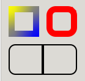

#### Parameters

| context | a GtkStyleContext |  |
| --- | --- | --- |
| cr | a [cairo_t](https://developer.gnome.org/cairo/stable/cairo-cairo-t.html#cairo-t) |  |
| x | X origin of the rectangle |  |
| y | Y origin of the rectangle |  |
| width | rectangle width |  |
| height | rectangle height |  |

Since: 3.0

### gtk_render_frame_gap ()

```
void
gtk_render_frame_gap (GtkStyleContext *context,
                      cairo_t *cr,
                      gdouble x,
                      gdouble y,
                      gdouble width,
                      gdouble height,
                      GtkPositionType gap_side,
                      gdouble xy0_gap,
                      gdouble xy1_gap);
```

`gtk_render_frame_gap` has been deprecated since version 3.24 and should not be used in newly-written code.

Use `gtk_render_frame()` instead. Themes can create gaps by omitting borders via CSS.

Renders a frame around the rectangle defined by (*`x`* , *`y`* , *`width`* , *`height`* ), leaving a gap on one side. *`xy0_gap`* and *`xy1_gap`* will mean X coordinates for `GTK_POS_TOP` and `GTK_POS_BOTTOM` gap sides, and Y coordinates for `GTK_POS_LEFT` and `GTK_POS_RIGHT`.

#### Parameters

| context | a GtkStyleContext |  |
| --- | --- | --- |
| cr | a [cairo_t](https://developer.gnome.org/cairo/stable/cairo-cairo-t.html#cairo-t) |  |
| x | X origin of the rectangle |  |
| y | Y origin of the rectangle |  |
| width | rectangle width |  |
| height | rectangle height |  |
| gap_side | side where the gap is |  |
| xy0_gap | initial coordinate (X or Y depending on *`gap_side`* ) for the gap |  |
| xy1_gap | end coordinate (X or Y depending on *`gap_side`* ) for the gap |  |

Since: 3.0

### gtk_render_handle ()

```
void
gtk_render_handle (GtkStyleContext *context,
                   cairo_t *cr,
                   gdouble x,
                   gdouble y,
                   gdouble width,
                   gdouble height);
```

Renders a handle (as in GtkHandleBox, GtkPaned and GtkWindow’s resize grip), in the rectangle determined by *`x`* , *`y`* , *`width`* , *`height`* .

#### Parameters

| context | a GtkStyleContext |  |
| --- | --- | --- |
| cr | a [cairo_t](https://developer.gnome.org/cairo/stable/cairo-cairo-t.html#cairo-t) |  |
| x | X origin of the rectangle |  |
| y | Y origin of the rectangle |  |
| width | rectangle width |  |
| height | rectangle height |  |

Since: 3.0

### gtk_render_layout ()

```
void
gtk_render_layout (GtkStyleContext *context,
                   cairo_t *cr,
                   gdouble x,
                   gdouble y,
                   PangoLayout *layout);
```

Renders *`layout`* on the coordinates *`x`* , *`y`*

#### Parameters

| context | a GtkStyleContext |  |
| --- | --- | --- |
| cr | a [cairo_t](https://developer.gnome.org/cairo/stable/cairo-cairo-t.html#cairo-t) |  |
| x | X origin |  |
| y | Y origin |  |
| layout | the [PangoLayout](https://developer.gnome.org/pango/stable/pango-Layout-Objects.html#PangoLayout-struct) to render |  |

Since: 3.0

### gtk_render_line ()

```
void
gtk_render_line (GtkStyleContext *context,
                 cairo_t *cr,
                 gdouble x0,
                 gdouble y0,
                 gdouble x1,
                 gdouble y1);
```

Renders a line from (x0, y0) to (x1, y1).

#### Parameters

| context | a GtkStyleContext |  |
| --- | --- | --- |
| cr | a [cairo_t](https://developer.gnome.org/cairo/stable/cairo-cairo-t.html#cairo-t) |  |
| x0 | X coordinate for the origin of the line |  |
| y0 | Y coordinate for the origin of the line |  |
| x1 | X coordinate for the end of the line |  |
| y1 | Y coordinate for the end of the line |  |

Since: 3.0

### gtk_render_option ()

```
void
gtk_render_option (GtkStyleContext *context,
                   cairo_t *cr,
                   gdouble x,
                   gdouble y,
                   gdouble width,
                   gdouble height);
```

Renders an option mark (as in a GtkRadioButton), the `GTK_STATE_FLAG_CHECKED` state will determine whether the option is on or off, and `GTK_STATE_FLAG_INCONSISTENT` whether it should be marked as undefined.

#### Parameters

| context | a GtkStyleContext |  |
| --- | --- | --- |
| cr | a [cairo_t](https://developer.gnome.org/cairo/stable/cairo-cairo-t.html#cairo-t) |  |
| x | X origin of the rectangle |  |
| y | Y origin of the rectangle |  |
| width | rectangle width |  |
| height | rectangle height |  |

Since: 3.0

### gtk_render_slider ()

```
void
gtk_render_slider (GtkStyleContext *context,
                   cairo_t *cr,
                   gdouble x,
                   gdouble y,
                   gdouble width,
                   gdouble height,
                   GtkOrientation orientation);
```

Renders a slider (as in GtkScale) in the rectangle defined by *`x`* , *`y`* , *`width`* , *`height`* . *`orientation`* defines whether the slider is vertical or horizontal.

#### Parameters

| context | a GtkStyleContext |  |
| --- | --- | --- |
| cr | a [cairo_t](https://developer.gnome.org/cairo/stable/cairo-cairo-t.html#cairo-t) |  |
| x | X origin of the rectangle |  |
| y | Y origin of the rectangle |  |
| width | rectangle width |  |
| height | rectangle height |  |
| orientation | orientation of the slider |  |

Since: 3.0

### gtk_render_activity ()

```
void
gtk_render_activity (GtkStyleContext *context,
                     cairo_t *cr,
                     gdouble x,
                     gdouble y,
                     gdouble width,
                     gdouble height);
```

Renders an activity indicator (such as in GtkSpinner). The state `GTK_STATE_FLAG_CHECKED` determines whether there is activity going on.

#### Parameters

| context | a GtkStyleContext |  |
| --- | --- | --- |
| cr | a [cairo_t](https://developer.gnome.org/cairo/stable/cairo-cairo-t.html#cairo-t) |  |
| x | X origin of the rectangle |  |
| y | Y origin of the rectangle |  |
| width | rectangle width |  |
| height | rectangle height |  |

Since: 3.0

### gtk_render_icon_pixbuf ()

```
GdkPixbuf *
gtk_render_icon_pixbuf (GtkStyleContext *context,
                        const GtkIconSource *source,
                        GtkIconSize size);
```

`gtk_render_icon_pixbuf` has been deprecated since version 3.10 and should not be used in newly-written code.

Use `gtk_icon_theme_load_icon()` instead.

Renders the icon specified by *`source`* at the given *`size`* , returning the result in a pixbuf.

#### Parameters

| context | a GtkStyleContext |  |
| --- | --- | --- |
| source | the GtkIconSource specifying the icon to render |  |
| size | the size (GtkIconSize) to render the icon at. A size of `(GtkIconSize) -1` means render at the size of the source and don’t scale. | [type int] |

#### Returns

a newly-created [GdkPixbuf](https://developer.gnome.org/gdk-pixbuf/unstable//gdk-pixbuf-The-GdkPixbuf-Structure.html#GdkPixbuf-struct) containing the rendered icon.

[transfer full]

Since: 3.0

### gtk_render_icon_surface ()

```
void
gtk_render_icon_surface (GtkStyleContext *context,
                         cairo_t *cr,
                         cairo_surface_t *surface,
                         gdouble x,
                         gdouble y);
```

Renders the icon in *`surface`* at the specified *`x`* and *`y`* coordinates.

#### Parameters

| context | a GtkStyleContext |  |
| --- | --- | --- |
| cr | a [cairo_t](https://developer.gnome.org/cairo/stable/cairo-cairo-t.html#cairo-t) |  |
| surface | a [cairo_surface_t](https://developer.gnome.org/cairo/stable/cairo-cairo-surface-t.html#cairo-surface-t) containing the icon to draw |  |
| x | X position for the *`icon`* |  |
| y | Y position for the *`incon`* |  |

Since: 3.10

### gtk_render_icon ()

```
void
gtk_render_icon (GtkStyleContext *context,
                 cairo_t *cr,
                 GdkPixbuf *pixbuf,
                 gdouble x,
                 gdouble y);
```

Renders the icon in *`pixbuf`* at the specified *`x`* and *`y`* coordinates.

This function will render the icon in *`pixbuf`* at exactly its size, regardless of scaling factors, which may not be appropriate when drawing on displays with high pixel densities.

You probably want to use `gtk_render_icon_surface()` instead, if you already have a Cairo surface.

#### Parameters

| context | a GtkStyleContext |  |
| --- | --- | --- |
| cr | a [cairo_t](https://developer.gnome.org/cairo/stable/cairo-cairo-t.html#cairo-t) |  |
| pixbuf | a [GdkPixbuf](https://developer.gnome.org/gdk-pixbuf/unstable//gdk-pixbuf-The-GdkPixbuf-Structure.html#GdkPixbuf-struct) containing the icon to draw |  |
| x | X position for the *`pixbuf`* |  |
| y | Y position for the *`pixbuf`* |  |

Since: 3.2

### gtk_render_insertion_cursor ()

```
void
gtk_render_insertion_cursor (GtkStyleContext *context,
                             cairo_t *cr,
                             gdouble x,
                             gdouble y,
                             PangoLayout *layout,
                             int index,
                             PangoDirection direction);
```

Draws a text caret on *`cr`* at the specified index of *`layout`* .

#### Parameters

| context | a GtkStyleContext |  |
| --- | --- | --- |
| cr | a [cairo_t](https://developer.gnome.org/cairo/stable/cairo-cairo-t.html#cairo-t) |  |
| x | X origin |  |
| y | Y origin |  |
| layout | the [PangoLayout](https://developer.gnome.org/pango/stable/pango-Layout-Objects.html#PangoLayout-struct) of the text |  |
| index | the index in the [PangoLayout](https://developer.gnome.org/pango/stable/pango-Layout-Objects.html#PangoLayout-struct) |  |
| direction | the PangoDirection of the text |  |

Since: 3.4

## Types and Values

### GTK_STYLE_PROPERTY_BACKGROUND_COLOR

```
#define GTK_STYLE_PROPERTY_BACKGROUND_COLOR "background-color"
```

A property holding the background color of rendered elements as a GdkRGBA.

### GTK_STYLE_PROPERTY_COLOR

```
#define GTK_STYLE_PROPERTY_COLOR "color"
```

A property holding the foreground color of rendered elements as a GdkRGBA.

### GTK_STYLE_PROPERTY_FONT

```
#define GTK_STYLE_PROPERTY_FONT "font"
```

A property holding the font properties used when rendering text as a [PangoFontDescription](https://developer.gnome.org/pango/stable/pango-Fonts.html#PangoFontDescription-struct).

### GTK_STYLE_PROPERTY_MARGIN

```
#define GTK_STYLE_PROPERTY_MARGIN "margin"
```

A property holding the rendered element’s margin as a GtkBorder. The margin is defined as the spacing between the border of the element and its surrounding elements. It is external to GtkWidget's size allocations, and the most external spacing property of the padding/border/margin series.

### GTK_STYLE_PROPERTY_PADDING

```
#define GTK_STYLE_PROPERTY_PADDING "padding"
```

A property holding the rendered element’s padding as a GtkBorder. The padding is defined as the spacing between the inner part of the element border and its child. It’s the innermost spacing property of the padding/border/margin series.

### GTK_STYLE_PROPERTY_BORDER_WIDTH

```
#define GTK_STYLE_PROPERTY_BORDER_WIDTH "border-width"
```

A property holding the rendered element’s border width in pixels as a GtkBorder. The border is the intermediary spacing property of the padding/border/margin series.

gtk_render_frame() uses this property to find out the frame line width, so GtkWidgets rendering frames may need to add up this padding when requesting size

### GTK_STYLE_PROPERTY_BORDER_RADIUS

```
#define GTK_STYLE_PROPERTY_BORDER_RADIUS "border-radius"
```

A property holding the rendered element’s border radius in pixels as a gint.

### GTK_STYLE_PROPERTY_BORDER_STYLE

```
#define GTK_STYLE_PROPERTY_BORDER_STYLE "border-style"
```

A property holding the element’s border style as a GtkBorderStyle.

### GTK_STYLE_PROPERTY_BORDER_COLOR

```
#define GTK_STYLE_PROPERTY_BORDER_COLOR "border-color"
```

A property holding the element’s border color as a GdkRGBA.

### GTK_STYLE_PROPERTY_BACKGROUND_IMAGE

```
#define GTK_STYLE_PROPERTY_BACKGROUND_IMAGE "background-image"
```

A property holding the element’s background as a [cairo_pattern_t](https://developer.gnome.org/cairo/stable/cairo-cairo-pattern-t.html#cairo-pattern-t).

### enum GtkBorderStyle

Describes how the border of a UI element should be rendered.

#### Members

| GTK_BORDER_STYLE_NONE | No visible border |  |
| --- | --- | --- |
| GTK_BORDER_STYLE_SOLID | A single line segment |  |
| GTK_BORDER_STYLE_INSET | Looks as if the content is sunken into the canvas |  |
| GTK_BORDER_STYLE_OUTSET | Looks as if the content is coming out of the canvas |  |
| GTK_BORDER_STYLE_HIDDEN | Same as *`GTK_BORDER_STYLE_NONE`* |  |
| GTK_BORDER_STYLE_DOTTED | A series of round dots |  |
| GTK_BORDER_STYLE_DASHED | A series of square-ended dashes |  |
| GTK_BORDER_STYLE_DOUBLE | Two parallel lines with some space between them |  |
| GTK_BORDER_STYLE_GROOVE | Looks as if it were carved in the canvas |  |
| GTK_BORDER_STYLE_RIDGE | Looks as if it were coming out of the canvas |  |

### GTK_STYLE_CLASS_ACCELERATOR

```
#define GTK_STYLE_CLASS_ACCELERATOR "accelerator"
```

A CSS class to match an accelerator.

Refer to individual widget documentation for used style classes.

### GTK_STYLE_CLASS_ARROW

```
#define GTK_STYLE_CLASS_ARROW "arrow"
```

A CSS class used when rendering an arrow element.

Refer to individual widget documentation for used style classes.

### GTK_STYLE_CLASS_BACKGROUND

```
#define GTK_STYLE_CLASS_BACKGROUND "background"
```

A CSS class to match the window background.

Refer to individual widget documentation for used style classes.

### GTK_STYLE_CLASS_BOTTOM

```
#define GTK_STYLE_CLASS_BOTTOM "bottom"
```

A CSS class to indicate an area at the bottom of a widget.

Refer to individual widget documentation for used style classes.

### GTK_STYLE_CLASS_BUTTON

```
#define GTK_STYLE_CLASS_BUTTON "button"
```

A CSS class to match buttons.

Refer to individual widget documentation for used style classes.

### GTK_STYLE_CLASS_CALENDAR

```
#define GTK_STYLE_CLASS_CALENDAR "calendar"
```

A CSS class to match calendars.

Refer to individual widget documentation for used style classes.

### GTK_STYLE_CLASS_CELL

```
#define GTK_STYLE_CLASS_CELL "cell"
```

A CSS class to match content rendered in cell views.

Refer to individual widget documentation for used style classes.

### GTK_STYLE_CLASS_COMBOBOX_ENTRY

```
#define GTK_STYLE_CLASS_COMBOBOX_ENTRY "combobox-entry"
```

A CSS class to match combobox entries.

Refer to individual widget documentation for used style classes.

### GTK_STYLE_CLASS_CONTEXT_MENU

```
#define GTK_STYLE_CLASS_CONTEXT_MENU "context-menu"
```

A CSS class to match context menus.

Refer to individual widget documentation for used style classes.

### GTK_STYLE_CLASS_CHECK

```
#define GTK_STYLE_CLASS_CHECK "check"
```

A CSS class to match check boxes.

Refer to individual widget documentation for used style classes.

### GTK_STYLE_CLASS_CSD

```
#define GTK_STYLE_CLASS_CSD "csd"
```

A CSS class that gets added to windows which have client-side decorations.

Refer to individual widget documentation for used style classes.

Since: 3.14

### GTK_STYLE_CLASS_CURSOR_HANDLE

```
#define GTK_STYLE_CLASS_CURSOR_HANDLE "cursor-handle"
```

A CSS class used when rendering a drag handle for text selection.

Refer to individual widget documentation for used style classes.

### GTK_STYLE_CLASS_DEFAULT

```
#define GTK_STYLE_CLASS_DEFAULT "default"
```

A CSS class to match the default widget.

Refer to individual widget documentation for used style classes.

### GTK_STYLE_CLASS_DESTRUCTIVE_ACTION

```
#define GTK_STYLE_CLASS_DESTRUCTIVE_ACTION "destructive-action"
```

A CSS class used when an action (usually a button) is one that is expected to remove or destroy something visible to the user.

Refer to individual widget documentation for used style classes.

Since: 3.12

### GTK_STYLE_CLASS_DIM_LABEL

```
#define GTK_STYLE_CLASS_DIM_LABEL "dim-label"
```

A CSS class to match dimmed labels.

Refer to individual widget documentation for used style classes.

### GTK_STYLE_CLASS_DND

```
#define GTK_STYLE_CLASS_DND "dnd"
```

A CSS class for a drag-and-drop indicator.

Refer to individual widget documentation for used style classes.

### GTK_STYLE_CLASS_DOCK

```
#define GTK_STYLE_CLASS_DOCK "dock"
```

A CSS class defining a dock area.

Refer to individual widget documentation for used style classes.

### GTK_STYLE_CLASS_ENTRY

```
#define GTK_STYLE_CLASS_ENTRY "entry"
```

A CSS class to match text entries.

Refer to individual widget documentation for used style classes.

### GTK_STYLE_CLASS_ERROR

```
#define GTK_STYLE_CLASS_ERROR "error"
```

A CSS class for an area displaying an error message, such as those in infobars.

Refer to individual widget documentation for used style classes.

### GTK_STYLE_CLASS_EXPANDER

```
#define GTK_STYLE_CLASS_EXPANDER "expander"
```

A CSS class defining an expander, such as those in treeviews.

Refer to individual widget documentation for used style classes.

### GTK_STYLE_CLASS_FRAME

```
#define GTK_STYLE_CLASS_FRAME "frame"
```

A CSS class defining a frame delimiting content, such as GtkFrame or the scrolled window frame around the scrollable area.

Refer to individual widget documentation for used style classes.

### GTK_STYLE_CLASS_FLAT

```
#define GTK_STYLE_CLASS_FLAT "flat"
```

A CSS class that is added when widgets that usually have a frame or border (like buttons or entries) should appear without it.

Refer to individual widget documentation for used style classes.

Since: 3.14

### GTK_STYLE_CLASS_GRIP

```
#define GTK_STYLE_CLASS_GRIP "grip"
```

A CSS class defining a resize grip.

Refer to individual widget documentation for used style classes.

### GTK_STYLE_CLASS_HEADER

```
#define GTK_STYLE_CLASS_HEADER "header"
```

A CSS class to match a header element.

Refer to individual widget documentation for used style classes.

### GTK_STYLE_CLASS_HIGHLIGHT

```
#define GTK_STYLE_CLASS_HIGHLIGHT "highlight"
```

A CSS class defining a highlighted area, such as headings in assistants and calendars.

Refer to individual widget documentation for used style classes.

### GTK_STYLE_CLASS_HORIZONTAL

```
#define GTK_STYLE_CLASS_HORIZONTAL "horizontal"
```

A CSS class for horizontally layered widgets.

Refer to individual widget documentation for used style classes.

### GTK_STYLE_CLASS_IMAGE

```
#define GTK_STYLE_CLASS_IMAGE "image"
```

A CSS class defining an image, such as the icon in an entry.

Refer to individual widget documentation for used style classes.

### GTK_STYLE_CLASS_INFO

```
#define GTK_STYLE_CLASS_INFO "info"
```

A CSS class for an area displaying an informational message, such as those in infobars.

Refer to individual widget documentation for used style classes.

### GTK_STYLE_CLASS_INLINE_TOOLBAR

```
#define GTK_STYLE_CLASS_INLINE_TOOLBAR "inline-toolbar"
```

A CSS class to match inline toolbars.

Refer to individual widget documentation for used style classes.

### GTK_STYLE_CLASS_INSERTION_CURSOR

```
#define GTK_STYLE_CLASS_INSERTION_CURSOR "insertion-cursor"
```

A CSS class used when rendering a drag handle for the insertion cursor position.

Refer to individual widget documentation for used style classes.

### GTK_STYLE_CLASS_LABEL

```
#define GTK_STYLE_CLASS_LABEL "label"
```

A CSS class to match labels.

Refer to individual widget documentation for used style classes.

Since: 3.16

### GTK_STYLE_CLASS_LEFT

```
#define GTK_STYLE_CLASS_LEFT "left"
```

A CSS class to indicate an area at the left of a widget.

Refer to individual widget documentation for used style classes.

### GTK_STYLE_CLASS_LEVEL_BAR

```
#define GTK_STYLE_CLASS_LEVEL_BAR "level-bar"
```

A CSS class used when rendering a level indicator, such as a battery charge level, or a password strength.

Refer to individual widget documentation for used style classes.

### GTK_STYLE_CLASS_LINKED

```
#define GTK_STYLE_CLASS_LINKED "linked"
```

A CSS class to match a linked area, such as a box containing buttons belonging to the same control.

Refer to individual widget documentation for used style classes.

### GTK_STYLE_CLASS_LIST

```
#define GTK_STYLE_CLASS_LIST "list"
```

A CSS class to match lists.

Refer to individual widget documentation for used style classes.

### GTK_STYLE_CLASS_LIST_ROW

```
#define GTK_STYLE_CLASS_LIST_ROW "list-row"
```

A CSS class to match list rows.

Refer to individual widget documentation for used style classes.

### GTK_STYLE_CLASS_MARK

```
#define GTK_STYLE_CLASS_MARK "mark"
```

A CSS class defining marks in a widget, such as in scales.

Refer to individual widget documentation for used style classes.

### GTK_STYLE_CLASS_MENU

```
#define GTK_STYLE_CLASS_MENU "menu"
```

A CSS class to match menus.

Refer to individual widget documentation for used style classes.

### GTK_STYLE_CLASS_MENUBAR

```
#define GTK_STYLE_CLASS_MENUBAR "menubar"
```

A CSS class to menubars.

Refer to individual widget documentation for used style classes.

### GTK_STYLE_CLASS_MENUITEM

```
#define GTK_STYLE_CLASS_MENUITEM "menuitem"
```

A CSS class to match menu items.

Refer to individual widget documentation for used style classes.

### GTK_STYLE_CLASS_MESSAGE_DIALOG

```
#define GTK_STYLE_CLASS_MESSAGE_DIALOG "message-dialog"
```

A CSS class that is added to message dialogs.

Refer to individual widget documentation for used style classes.

Since: 3.14

### GTK_STYLE_CLASS_MONOSPACE

```
#define GTK_STYLE_CLASS_MONOSPACE "monospace"
```

A CSS class that is added to text view that should use a monospace font.

Refer to individual widget documentation for used style classes.

Since: 3.16

### GTK_STYLE_CLASS_NEEDS_ATTENTION

```
#define GTK_STYLE_CLASS_NEEDS_ATTENTION "needs-attention"
```

A CSS class used when an element needs the user attention, for instance a button in a stack switcher corresponding to a hidden page that changed state.

Refer to individual widget documentation for used style classes.

Since: 3.12

### GTK_STYLE_CLASS_NOTEBOOK

```
#define GTK_STYLE_CLASS_NOTEBOOK "notebook"
```

A CSS class defining a notebook.

Refer to individual widget documentation for used style classes.

### GTK_STYLE_CLASS_OSD

```
#define GTK_STYLE_CLASS_OSD "osd"
```

A CSS class used when rendering an OSD (On Screen Display) element, on top of another container.

Refer to individual widget documentation for used style classes.

### GTK_STYLE_CLASS_OVERSHOOT

```
#define GTK_STYLE_CLASS_OVERSHOOT "overshoot"
```

A CSS class that is added on the visual hints that happen when scrolling is attempted past the limits of a scrollable area.

Refer to individual widget documentation for used style classes.

Since: 3.14

### GTK_STYLE_CLASS_PANE_SEPARATOR

```
#define GTK_STYLE_CLASS_PANE_SEPARATOR "pane-separator"
```

A CSS class for a pane separator, such as those in GtkPaned.

Refer to individual widget documentation for used style classes.

### GTK_STYLE_CLASS_PAPER

```
#define GTK_STYLE_CLASS_PAPER "paper"
```

A CSS class that is added to areas that should look like paper.

This is used in print previews and themes are encouraged to style it as black text on white background.

Refer to individual widget documentation for used style classes.

Since: 3.16

### GTK_STYLE_CLASS_POPUP

```
#define GTK_STYLE_CLASS_POPUP "popup"
```

A CSS class that is added to the toplevel windows used for menus.

Refer to individual widget documentation for used style classes.

Since: 3.14

### GTK_STYLE_CLASS_POPOVER

```
#define GTK_STYLE_CLASS_POPOVER "popover"
```

A CSS class that matches popovers.

Refer to individual widget documentation for used style classes.

Since: 3.14

### GTK_STYLE_CLASS_PRIMARY_TOOLBAR

```
#define GTK_STYLE_CLASS_PRIMARY_TOOLBAR "primary-toolbar"
```

A CSS class to match primary toolbars.

Refer to individual widget documentation for used style classes.

### GTK_STYLE_CLASS_PROGRESSBAR

```
#define GTK_STYLE_CLASS_PROGRESSBAR "progressbar"
```

A CSS class to use when rendering activity as a progressbar.

Refer to individual widget documentation for used style classes.

### GTK_STYLE_CLASS_PULSE

```
#define GTK_STYLE_CLASS_PULSE "pulse"
```

A CSS class to use when rendering a pulse in an indeterminate progress bar.

Refer to individual widget documentation for used style classes.

### GTK_STYLE_CLASS_QUESTION

```
#define GTK_STYLE_CLASS_QUESTION "question"
```

A CSS class for an area displaying a question to the user, such as those in infobars.

Refer to individual widget documentation for used style classes.

### GTK_STYLE_CLASS_RADIO

```
#define GTK_STYLE_CLASS_RADIO "radio"
```

A CSS class to match radio buttons.

Refer to individual widget documentation for used style classes.

### GTK_STYLE_CLASS_RAISED

```
#define GTK_STYLE_CLASS_RAISED "raised"
```

A CSS class to match a raised control, such as a raised button on a toolbar.

Refer to individual widget documentation for used style classes.

### GTK_STYLE_CLASS_READ_ONLY

```
#define GTK_STYLE_CLASS_READ_ONLY "read-only"
```

A CSS class used to indicate a read-only state.

Refer to individual widget documentation for used style classes.

### GTK_STYLE_CLASS_RIGHT

```
#define GTK_STYLE_CLASS_RIGHT "right"
```

A CSS class to indicate an area at the right of a widget.

Refer to individual widget documentation for used style classes.

### GTK_STYLE_CLASS_RUBBERBAND

```
#define GTK_STYLE_CLASS_RUBBERBAND "rubberband"
```

A CSS class to match the rubberband selection rectangle.

Refer to individual widget documentation for used style classes.

### GTK_STYLE_CLASS_SCALE

```
#define GTK_STYLE_CLASS_SCALE "scale"
```

A CSS class to match scale widgets.

Refer to individual widget documentation for used style classes.

### GTK_STYLE_CLASS_SCALE_HAS_MARKS_ABOVE

```
#define GTK_STYLE_CLASS_SCALE_HAS_MARKS_ABOVE "scale-has-marks-above"
```

A CSS class to match scale widgets with marks attached, all the marks are above for horizontal GtkScale. left for vertical GtkScale.

Refer to individual widget documentation for used style classes.

### GTK_STYLE_CLASS_SCALE_HAS_MARKS_BELOW

```
#define GTK_STYLE_CLASS_SCALE_HAS_MARKS_BELOW "scale-has-marks-below"
```

A CSS class to match scale widgets with marks attached, all the marks are below for horizontal GtkScale, right for vertical GtkScale.

Refer to individual widget documentation for used style classes.

### GTK_STYLE_CLASS_SCROLLBAR

```
#define GTK_STYLE_CLASS_SCROLLBAR "scrollbar"
```

A CSS class to match scrollbars.

Refer to individual widget documentation for used style classes.

### GTK_STYLE_CLASS_SCROLLBARS_JUNCTION

```
#define GTK_STYLE_CLASS_SCROLLBARS_JUNCTION "scrollbars-junction"
```

A CSS class to match the junction area between an horizontal and vertical scrollbar, when they’re both shown.

Refer to individual widget documentation for used style classes.

### GTK_STYLE_CLASS_SEPARATOR

```
#define GTK_STYLE_CLASS_SEPARATOR "separator"
```

A CSS class for a separator.

Refer to individual widget documentation for used style classes.

### GTK_STYLE_CLASS_SIDEBAR

```
#define GTK_STYLE_CLASS_SIDEBAR "sidebar"
```

A CSS class defining a sidebar, such as the left side in a file chooser.

Refer to individual widget documentation for used style classes.

### GTK_STYLE_CLASS_SLIDER

```
#define GTK_STYLE_CLASS_SLIDER "slider"
```

A CSS class to match sliders.

Refer to individual widget documentation for used style classes.

### GTK_STYLE_CLASS_SPINBUTTON

```
#define GTK_STYLE_CLASS_SPINBUTTON "spinbutton"
```

A CSS class defining an spinbutton.

Refer to individual widget documentation for used style classes.

### GTK_STYLE_CLASS_SPINNER

```
#define GTK_STYLE_CLASS_SPINNER "spinner"
```

A CSS class to use when rendering activity as a “spinner”.

Refer to individual widget documentation for used style classes.

### GTK_STYLE_CLASS_STATUSBAR

```
#define GTK_STYLE_CLASS_STATUSBAR "statusbar"
```

A CSS class to match statusbars.

Refer to individual widget documentation for used style classes.

Since: 3.16

### GTK_STYLE_CLASS_SUBTITLE

```
#define GTK_STYLE_CLASS_SUBTITLE "subtitle"
```

A CSS class used for the subtitle label in a titlebar in a toplevel window.

Refer to individual widget documentation for used style classes.

Since: 3.14

### GTK_STYLE_CLASS_SUGGESTED_ACTION

```
#define GTK_STYLE_CLASS_SUGGESTED_ACTION "suggested-action"
```

A CSS class used when an action (usually a button) is the primary suggested action in a specific context.

Refer to individual widget documentation for used style classes.

Since: 3.12

### GTK_STYLE_CLASS_TITLE

```
#define GTK_STYLE_CLASS_TITLE "title"
```

A CSS class used for the title label in a titlebar in a toplevel window.

Refer to individual widget documentation for used style classes.

Since: 3.14

### GTK_STYLE_CLASS_TITLEBAR

```
#define GTK_STYLE_CLASS_TITLEBAR "titlebar"
```

A CSS class used when rendering a titlebar in a toplevel window.

Refer to individual widget documentation for used style classes.

### GTK_STYLE_CLASS_TOOLBAR

```
#define GTK_STYLE_CLASS_TOOLBAR "toolbar"
```

A CSS class to match toolbars.

Refer to individual widget documentation for used style classes.

### GTK_STYLE_CLASS_TOOLTIP

```
#define GTK_STYLE_CLASS_TOOLTIP "tooltip"
```

A CSS class to match tooltip windows.

Refer to individual widget documentation for used style classes.

### GTK_STYLE_CLASS_TOUCH_SELECTION

```
#define GTK_STYLE_CLASS_TOUCH_SELECTION "touch-selection"
```

A CSS class for touch selection popups on entries and text views.

Refer to individual widget documentation for used style classes.

Since: 3.16

### GTK_STYLE_CLASS_TOP

```
#define GTK_STYLE_CLASS_TOP "top"
```

A CSS class to indicate an area at the top of a widget.

Refer to individual widget documentation for used style classes.

### GTK_STYLE_CLASS_TROUGH

```
#define GTK_STYLE_CLASS_TROUGH "trough"
```

A CSS class to match troughs, as in scrollbars and progressbars.

Refer to individual widget documentation for used style classes.

### GTK_STYLE_CLASS_UNDERSHOOT

```
#define GTK_STYLE_CLASS_UNDERSHOOT "undershoot"
```

A CSS class that is added on the visual hints that happen where content is 'scrolled off' and can be made visible by scrolling.

Refer to individual widget documentation for used style classes.

Since: 3.16

### GTK_STYLE_CLASS_VERTICAL

```
#define GTK_STYLE_CLASS_VERTICAL "vertical"
```

A CSS class for vertically layered widgets.

Refer to individual widget documentation for used style classes.

### GTK_STYLE_CLASS_VIEW

```
#define GTK_STYLE_CLASS_VIEW "view"
```

A CSS class defining a view, such as iconviews or treeviews.

Refer to individual widget documentation for used style classes.

### GTK_STYLE_CLASS_WARNING

```
#define GTK_STYLE_CLASS_WARNING "warning"
```

A CSS class for an area displaying a warning message, such as those in infobars.

Refer to individual widget documentation for used style classes.

### GTK_STYLE_CLASS_WIDE

```
#define GTK_STYLE_CLASS_WIDE "wide"
```

A CSS class to indicate that a UI element should be 'wide'. Used by GtkPaned.

Refer to individual widget documentation for used style classes.

Since: 3.16

### GTK_STYLE_REGION_COLUMN

```
#define GTK_STYLE_REGION_COLUMN "column"
```

`GTK_STYLE_REGION_COLUMN` has been deprecated since version 3.20 and should not be used in newly-written code.

Don't use regions.

A widget region name to define a treeview column.

### GTK_STYLE_REGION_COLUMN_HEADER

```
#define GTK_STYLE_REGION_COLUMN_HEADER "column-header"
```

`GTK_STYLE_REGION_COLUMN_HEADER` has been deprecated since version 3.20 and should not be used in newly-written code.

Don't use regions.

A widget region name to define a treeview column header.

### GTK_STYLE_REGION_ROW

```
#define GTK_STYLE_REGION_ROW "row"
```

`GTK_STYLE_REGION_ROW` has been deprecated since version 3.20 and should not be used in newly-written code.

Don't use regions.

A widget region name to define a treeview row.

### GTK_STYLE_REGION_TAB

```
#define GTK_STYLE_REGION_TAB "tab"
```

`GTK_STYLE_REGION_TAB` has been deprecated since version 3.20 and should not be used in newly-written code.

Don't use regions.

A widget region name to define a notebook tab.

### GtkStyleContext

```
typedef struct _GtkStyleContext GtkStyleContext;
```

### enum GtkJunctionSides

Describes how a rendered element connects to adjacent elements.

#### Members

| GTK_JUNCTION_NONE | No junctions. |  |
| --- | --- | --- |
| GTK_JUNCTION_CORNER_TOPLEFT | Element connects on the top-left corner. |  |
| GTK_JUNCTION_CORNER_TOPRIGHT | Element connects on the top-right corner. |  |
| GTK_JUNCTION_CORNER_BOTTOMLEFT | Element connects on the bottom-left corner. |  |
| GTK_JUNCTION_CORNER_BOTTOMRIGHT | Element connects on the bottom-right corner. |  |
| GTK_JUNCTION_TOP | Element connects on the top side. |  |
| GTK_JUNCTION_BOTTOM | Element connects on the bottom side. |  |
| GTK_JUNCTION_LEFT | Element connects on the left side. |  |
| GTK_JUNCTION_RIGHT | Element connects on the right side. |  |

### enum GtkRegionFlags

Describes a region within a widget.

#### Members

| GTK_REGION_EVEN | Region has an even number within a set. |  |
| --- | --- | --- |
| GTK_REGION_ODD | Region has an odd number within a set. |  |
| GTK_REGION_FIRST | Region is the first one within a set. |  |
| GTK_REGION_LAST | Region is the last one within a set. |  |
| GTK_REGION_ONLY | Region is the only one within a set. |  |
| GTK_REGION_SORTED | Region is part of a sorted area. |  |

### enum GtkStyleContextPrintFlags

Flags that modify the behavior of `gtk_style_context_to_string()`. New values may be added to this enumeration.

#### Members

| GTK_STYLE_CONTEXT_PRINT_NONE |  |  |
| --- | --- | --- |
| GTK_STYLE_CONTEXT_PRINT_RECURSE | Print the entire tree of CSS nodes starting at the style context's node |  |
| GTK_STYLE_CONTEXT_PRINT_SHOW_STYLE | Show the values of the CSS properties for each node |  |

### struct GtkBorder

```
struct GtkBorder {
  gint16 left;
  gint16 right;
  gint16 top;
  gint16 bottom;
};
```

A struct that specifies a border around a rectangular area that can be of different width on each side.

#### Members

| gint16 *`left`*; | The width of the left border |  |
| --- | --- | --- |
| gint16 *`right`*; | The width of the right border |  |
| gint16 *`top`*; | The width of the top border |  |
| gint16 *`bottom`*; | The width of the bottom border |  |

## Property Details

### The `“direction”` property

```
  “direction”                GtkTextDirection
```

Text direction.

Owner: GtkStyleContext

Flags: Read / Write

Default value: GTK_TEXT_DIR_LTR

### The `“paint-clock”` property

```
  “paint-clock”              GdkFrameClock *
```

The associated GdkFrameClock.

Owner: GtkStyleContext

Flags: Read / Write

### The `“parent”` property

```
  “parent”                   GtkStyleContext *
```

Sets or gets the style context’s parent. See `gtk_style_context_set_parent()` for details.

Owner: GtkStyleContext

Flags: Read / Write

Since: 3.4

### The `“screen”` property

```
  “screen”                   GdkScreen *
```

The associated GdkScreen.

Owner: GtkStyleContext

Flags: Read / Write

## Signal Details

### The `“changed”` signal

```
void
user_function (GtkStyleContext *stylecontext,
               gpointer         user_data)
```

The ::changed signal is emitted when there is a change in the GtkStyleContext.

For a GtkStyleContext returned by `gtk_widget_get_style_context()`, the “style-updated” signal/vfunc might be more convenient to use.

This signal is useful when using the theming layer standalone.

#### Parameters

| user_data | user data set when the signal handler was connected. |  |
| --- | --- | --- |

Flags: Run First

Since: 3.0

© 2005–2020 The GNOME Project  
Licensed under the GNU Lesser General Public License version 2.1 or later.  
https://developer.gnome.org/gtk3/3.24/GtkStyleContext.html